# Tutorial 2: Cell Embedding with C2S

In this tutorial, we will demonstrate how to perform cell embedding using the Cell2Sentence (C2S) models. Cell embeddings are crucial for downstream tasks such as clustering, visualization, and classification. By converting cells into embeddings, we create a compact representation that captures the essential information from the cell sentences.

In this tutorial, you will:

1. Load an immune tissue single-cell dataset from Domínguez Conde et al. (preprocessed in tutorial notebook 0, two sample donors), and create a CSData() wrapper around it
   - Citation: Domínguez Conde, C., et al. "Cross-tissue immune cell analysis reveals tissue-specific features in humans." Science 376.6594 (2022): eabl5197.
2. Load a pretrained C2S model and create a CSModel object.
3. Embed the cells using the C2S model.
4. Visualize the cell embeddings to gain insights into the data.

We will begin by importing the necessary libraries. These include Python's built-in libraries, third-party libraries for handling numerical computations, progress tracking, and specific libraries for single-cell RNA sequencing data and C2S operations.

```python
######## Load modules ########
from __future__ import annotations #default now for name.error issue
import os
import numpy as np
import random
import pandas as pd
import matplotlib.pyplot as plt
import seaborn as sns
SEED = 1234
random.seed(SEED)
np.random.seed(SEED)
import scipy
from tqdm import tqdm

# Cell2Sentence imports
import cell2sentence as cs
from cell2sentence.utils import benchmark_expression_conversion, reconstruct_expression_from_cell_sentence
from cell2sentence.tasks import embed_cells

# Single-cell libraries
import scanpy as sc
import anndata as ad
from collections import Counter #count table

sc.set_figure_params(dpi=300, color_map="viridis_r", facecolor="white", )
sc.settings.verbosity = 3  # verbosity: errors (0), warnings (1), info (2), hints (3)
sc.logging.print_header()
```

```
scanpy==1.9.8 anndata==0.9.2 umap==0.5.7 numpy==1.24.4 scipy==1.10.1 pandas==2.0.3 scikit-learn==1.3.2 statsmodels==0.14.1 pynndescent==0.5.13
```

# Load Data

Next, we will load the preprocessed dataset from the tutorial 0. This dataset has already been filtered and normalized, so it it ready for transformation into cell sentences.

Please make sure you have completed the preprocessing steps in Tutorial 0 before running the following code, if you are using your own dataset.. Ensure that the file path is correctly set in DATA_PATH to where your preprocessed data was saved from tutorial 0.

```python
DATA_PATH = "/ix/ccdg/storage3/til177/ParkLab/Project_C2S_scFM/code/tutorials/dominguez_conde_immune_tissue_two_donors_preprocessed_tutorial_0_PYFILE.h5ad"
```

```python
adata = ad.read_h5ad(DATA_PATH)
adata
```

```
AnnData object with n_obs × n_vars = 29773 × 23944
    obs: 'cell_type', 'tissue', 'batch_condition', 'organism', 'assay', 'sex', 'n_genes', 'n_genes_by_counts', 'total_counts', 'total_counts_mt', 'pct_counts_mt'
    var: 'gene_name', 'ensembl_id', 'n_cells', 'mt', 'n_cells_by_counts', 'mean_counts', 'pct_dropout_by_counts', 'total_counts'
    uns: 'batch_condition_colors', 'cell_type_colors', 'log1p', 'neighbors', 'pca', 'tissue_colors', 'umap'
    obsm: 'X_pca', 'X_umap'
    varm: 'PCs'
    obsp: 'connectivities', 'distances'
```

```python
adata.obs = adata.obs[["cell_type", "tissue", "batch_condition", "organism", "sex"]]
```

```python
adata.obs.head()
```

|  | cell_type | tissue | batch_condition | organism | sex |
| --- | --- | --- | --- | --- | --- |
| Pan_T7935490_AAACCTGCAAATTGCC | CD4-positive helper T cell | ileum | A29 | Homo sapiens | female |
| Pan_T7935490_AAACGGGCATCTGGTA | CD8-positive, alpha-beta memory T cell | ileum | A29 | Homo sapiens | female |
| Pan_T7935490_AAACGGGTCTTGCATT | CD8-positive, alpha-beta memory T cell | ileum | A29 | Homo sapiens | female |
| Pan_T7935490_AAAGCAATCATCGCTC | CD8-positive, alpha-beta memory T cell | ileum | A29 | Homo sapiens | female |
| Pan_T7935490_AAAGTAGCAGTCACTA | gamma-delta T cell | ileum | A29 | Homo sapiens | female |

```python
adata.var.head()
```

|  | gene_name | ensembl_id | n_cells | mt | n_cells_by_counts | mean_counts | pct_dropout_by_counts | total_counts |
| --- | --- | --- | --- | --- | --- | --- | --- | --- |
| RP11-34P13 | RP11-34P13 | ENSG00000238009 | 38 | False | 38 | 0.001310 | 99.872368 | 39.0 |
| RP11-34P13-3 | RP11-34P13 | ENSG00000241860 | 106 | False | 106 | 0.003627 | 99.643973 | 108.0 |
| AP006222 | AP006222 | ENSG00000286448 | 7 | False | 7 | 0.000235 | 99.976489 | 7.0 |
| LINC01409 | LINC01409 | ENSG00000237491 | 1292 | False | 1292 | 0.045981 | 95.660498 | 1369.0 |
| FAM87B | FAM87B | ENSG00000177757 | 3 | False | 3 | 0.000101 | 99.989924 | 3.0 |

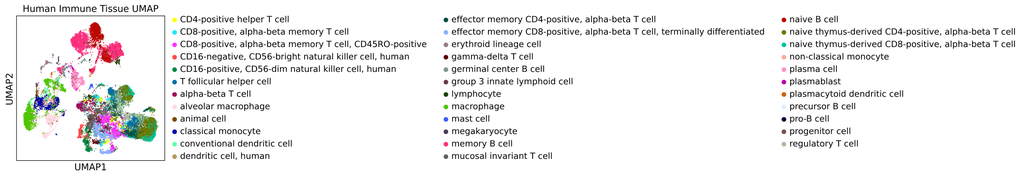

```python
sc.pl.umap(
    adata,
    color="cell_type",
    size=8,
    title="Human Immune Tissue UMAP",
)
```

```python
adata.X.max()
```

```
3.408124
```

We are expecting log10 base 10 transformed data, with a maximum value somewhere around 3 or 4. Make sure to start with processed and normalized data when doing the cell sentence conversion!

# Cell2Sentence Conversion + CSData Creation

In this section, we will transform our AnnData object containing our single-cell dataset into a Cell2Sentence (C2S) dataset by calling the functions of the CSData class in the C2S code base. Full documentation for the functions of the CSData class can be found in the documentation page of C2S.

```python
adata_obs_cols_to_keep = ["cell_type", "tissue", "batch_condition", "organism", "sex"]
```

```python
# Create CSData object
arrow_ds, vocabulary = cs.CSData.adata_to_arrow(
    adata=adata,
    random_state=SEED,
    sentence_delimiter=' ',
    label_col_names=adata_obs_cols_to_keep
)
```

We can visualize one sample of our created arrow dataset as follows:

```python
sample_idx = 0
arrow_ds[sample_idx]
```

```
{'cell_name': 'Pan_T7935490_AAACCTGCAAATTGCC',
 'cell_sentence': 'RPLP1 ACTB EEF1A1 HSP90AA1 TMSB4X B2M FTH1 KLF6 HSPA1B MALAT1 RPS12 HSPA8 RPL13 MT-CO1 ATF3 MT-CO2 RPL41 TPT1 MT-CO3 RPS19 HLA-B RPL10 RPS4X RPL28 MT-CYB DUSP1 RPL30 MT-ND4L RPS15 FOS RPL34 RPS2 RPLP2 MT-ND3 RPS18 RPS8 TRBV7-2 RPL32 RPS3 ANXA1 RPL11 HLA-C RPS27 ACTG1 UBC RPL3 RPL3…
 'cell_type': 'CD4-positive helper T cell',
 'tissue': 'ileum',
 'batch_condition': 'A29',
 'organism': 'Homo sapiens',
 'sex': 'female'}
```

```python
c2s_save_dir = "/ix/ccdg/storage3/til177/ParkLab/Project_C2S_scFM/code/tutorials"  # C2S dataset will be saved into this directory
c2s_save_name = "dominguez_immune_tissue_tutorial2"  # This will be the name of our C2S dataset on disk
```

```python
csdata = cs.CSData.csdata_from_arrow(
    arrow_dataset=arrow_ds,
    vocabulary=vocabulary,
    save_dir=c2s_save_dir,
    save_name=c2s_save_name,
    dataset_backend="arrow"
)
```

```python
print(csdata)
```

```
CSData Object; Path=/ix/ccdg/storage3/til177/ParkLab/Project_C2S_scFM/code/tutorials/dominguez_immune_tissue_tutorial2, Format=arrow
```

We can retrieve the cell sentences from our dataset using the get_sentence_strings() function of our csdata object:

```python
cell_sentences_list = csdata.get_sentence_strings()
```

```python
def print_first_N_genes(cell_sentence_str: str, top_k_genes: int, delimiter: str = " "):
    """Helper function to print K genes of a cell sentence."""
    print(delimiter.join(cell_sentence_str.split(delimiter)[:top_k_genes]))
```

```python
print_first_N_genes(cell_sentences_list[0], top_k_genes=200)
```

```
RPLP1 ACTB EEF1A1 HSP90AA1 TMSB4X B2M FTH1 KLF6 HSPA1B MALAT1 RPS12 HSPA8 RPL13 MT-CO1 ATF3 MT-CO2 RPL41 TPT1 MT-CO3 RPS19 HLA-B RPL10 RPS4X RPL28 MT-CYB DUSP1 RPL30 MT-ND4L RPS15 FOS RPL34 RPS2 RPLP2 MT-ND3 RPS18 RPS8 TRBV7-2 RPL32 RPS3 ANXA1 RPL11 HLA-C RPS27 ACTG1 UBC RPL3 RPL37 RPLP0 MT-ATP6 JUN…
```

```python
print_first_N_genes(cell_sentences_list[1], top_k_genes=200)
```

```
TMSB4X MT-CO1 B2M MT-CO2 MALAT1 HSPA1A ACTB HSP90AA1 RPLP1 MT-CO3 MT-CYB RPS27 JUNB MT-ND3 EEF1A1 HSPA1B HLA-B RPL41 RPS18 CD69 DNAJB1 JUN CCL5 RPL10 RPL28 FOS MT-ND4L MT-ATP8 RPS19 IL32 TPT1 RPL39 IFNG RPL13 FTH1 PPP1R15A RPS15A RPS14 PFN1 ZFP36 HLA-C CD52 EIF1 SH3BGRL3 PTMA MT-ATP6 RPS12 FTL ACTG1…
```

# Cell embedding

Now, we will embed cells using C2S. First, we need to load a pretrained C2S model which we will do cell embedding with. Any C2S model would do here for extracting embeddings, however we strongly recommend C2S models which have been trained to do cell type or tissue prediction.

We can define our CSModel object with our pretrained cell type prediction model as follows:

```python
# Define CSModel object
cell_type_prediction_model_path = "/ix/ccdg/storage3/til177/ParkLab/Project_C2S_scFM/C2S_models/C2S-Pythia-410m-diverse-single-and-multi-cell-tasks/snapshots/51f7c9d46776273ea4732ddaf494d1db733ca5d6"
save_dir = "/ix/ccdg/storage3/til177/ParkLab/Project_C2S_scFM/code/tutorials/csmodel_tutorial_2"
save_name = "cell_embedding_prediction_pythia_410M_1"
csmodel = cs.CSModel(
    model_name_or_path=cell_type_prediction_model_path,
    save_dir=save_dir,
    save_name=save_name
)
```

```
Using device: cpu
```

```python
print(csmodel)
```

```
CSModel Object; Path=/ix/ccdg/storage3/til177/ParkLab/Project_C2S_scFM/code/tutorials/csmodel_tutorial_2/cell_embedding_prediction_pythia_410M_1
```

```python
print(csdata)
adata.shape[0]
```

```
CSData Object; Path=/ix/ccdg/storage3/til177/ParkLab/Project_C2S_scFM/code/tutorials/dominguez_immune_tissue_tutorial2, Format=arrow
```

```
29773
```

We will use the `embed_cells()` function from tasks.py to **obtain cell embeddings using our C2S model**. The function takes as input a CSData and CSModel objects, as well as the number of genes to use per cell sentence. It will:

1. Load the C2S model and data
2. Format the cell sentences into prompts for cell type prediction
3. Run the prompts through the C2S model
4. Collect and return cell embeddings

```python
# Embed cells
embedded_cells = embed_cells(
    csdata=csdata,
    csmodel=csmodel,
    n_genes=200,
)
```

```
Reloading model from path on disk: /ix/ccdg/storage3/til177/ParkLab/Project_C2S_scFM/code/tutorials/csmodel_tutorial_2/cell_embedding_prediction_pythia_410M_1
Embedding 29773 cells using CSModel...
```

```python
embedded_cells.shape
```

```
(29773, 1024)
```

```python
# output Numpy array of embedded cells
save_dir = "/ix/ccdg/storage3/til177/ParkLab/Project_C2S_scFM/code/tutorials/csmodel_tutorial_2"
save_dir+"/CSModel_pythia_410M_1__cell_embeddings.npy"
```

```
'/ix/ccdg/storage3/til177/ParkLab/Project_C2S_scFM/code/tutorials/csmodel_tutorial_2/CSModel_pythia_410M_1__cell_embeddings.npy'
```

Now, we create a UMAP of the cell embeddings to visualize the embeddings obtained from the C2S model. We will add the cell embeddings to our adata object, and rerun the neighbors and UMAP algorithms in Scanpy using the cell embeddings.

```python
del adata.uns
del adata.obsm
del adata.varm
del adata.obsp
```

```python
adata
```

```
AnnData object with n_obs × n_vars = 29773 × 23944
    obs: 'cell_type', 'tissue', 'batch_condition', 'organism', 'sex'
    var: 'gene_name', 'ensembl_id', 'n_cells', 'mt', 'n_cells_by_counts', 'mean_counts', 'pct_dropout_by_counts', 'total_counts'
```

```python
adata.obsm["c2s_cell_embeddings"] = embedded_cells
```

```python
adata
```

```
AnnData object with n_obs × n_vars = 29773 × 23944
    obs: 'cell_type', 'tissue', 'batch_condition', 'organism', 'sex'
    var: 'gene_name', 'ensembl_id', 'n_cells', 'mt', 'n_cells_by_counts', 'mean_counts', 'pct_dropout_by_counts', 'total_counts'
    obsm: 'c2s_cell_embeddings'
```

```python
sc.pp.neighbors(adata, use_rep="c2s_cell_embeddings")  # calculate neighbors using cell embeddings
```

```python
sc.tl.umap(adata)
```

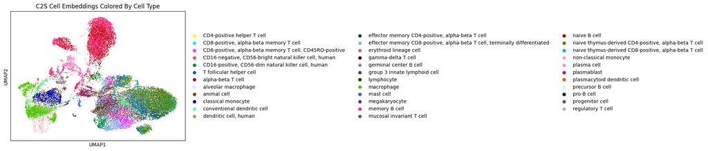

```python
sc.pl.umap(
    adata,
    color="cell_type",
    size=8,
    title="C2S Cell Embeddings Colored By Cell Type",
)
```

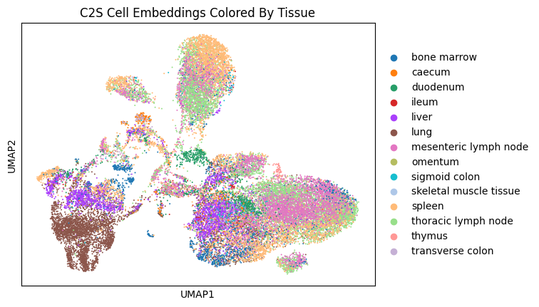

```python
sc.pl.umap(
    adata,
    color="tissue",
    size=8,
    title="C2S Cell Embeddings Colored By Tissue",
)
```

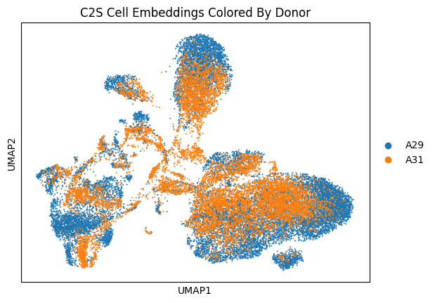

```python
sc.pl.umap(
    adata,
    color="batch_condition",
    size=8,
    title="C2S Cell Embeddings Colored By Donor",
)
```